# Police Sentiment Data Analysis

Riley Harper

2/19/2022

# Load Libraries and Data

## The Data

### First 5 rows of the dataset

```r
head(eda_sentiment, 5)
```

```
## # A tibble: 5 x 23
##   community      safety s_race_african_american s_race_asian_am~ s_race_hispanic
##   <chr>           <dbl>                   <dbl>            <dbl>           <dbl>
## 1 Rogers Park      61.0                    61.4             61.5            59.4
## 2 West Ridge       63.3                    62.2             63.7            61.9
## 3 Uptown           66.3                    61.8             62.0            64.4
## 4 Lincoln Square   67.7                    62.8             62.8            67.2
## 5 North Center     67.2                    61.8             62.3            66.0
## # ... with 18 more variables: s_race_white <dbl>, s_race_other <dbl>,
## #   s_age_low <dbl>, s_age_medium <dbl>, s_age_high <dbl>, s_sex_female <dbl>,
## #   s_sex_male <dbl>, trust <dbl>, t_race_african_american <dbl>,
## #   t_race_asian_american <dbl>, t_race_hispanic <dbl>, t_race_white <dbl>,
## #   t_race_other <dbl>, t_age_low <dbl>, t_age_medium <dbl>, t_age_high <dbl>,
## #   t_sex_female <dbl>, t_sex_male <dbl>
```

### Description of the Dataset

This data is sourced by the Chicago Police.

In this dataset, each row represents one of the 77 communities, hence the 77 rows of data. There are two main measures from the Police Sentiment Report to analyze: Safety and Trust. Each row contains both a Safety and Trust score from the entire community.

This dataset allows us to look at the breakout of Trust and Safety scores across race, age, and sex demographics.

Here are the options for each demographic:  
Race: African American, Asian American, Hispanic, White, Other  
Age: Low, Medium, High  
Sex: Female, Male

### Dataset Considerations

On the topic of race:  
4 options for race and one other option does not allow for a sophisticated breakdown of ethnicity. The police have bucketed race into very broad categories and thus this analysis will also make claims that must be prefaced with this datasets broad bucketing of race.

On the topic of sex and gender: Two sexes are listed without the inclusion of intersex. Gender is also not considered, and therefore this analysis is limited to a binary analysis between the male and female sexes.

This data set does not let us directly observe demographics of multiple characteristics of interest from their survey results. For example, we cannot analyze the trust score of middle aged female asian-americans. Access to those raw survey results is not available.

I am curious to see how the Chicago Police decided to break the demographics compares to the census team’s work.

# Introduction to Variables

```r
describe(eda_sentiment)
```

```
## # A tibble: 22 x 26
##    variable      n    na  mean    sd se_mean   IQR skewness kurtosis   p00   p01
##    <chr>     <int> <int> <dbl> <dbl>   <dbl> <dbl>    <dbl>    <dbl> <dbl> <dbl>
##  1 safety       77     0  57.7  5.91   0.674  9.82   0.373    -1.09   49.1  49.2
##  2 s_race_a~    77     0  54.9  4.29   0.489  6.69   0.247    -0.967  47.1  47.3
##  3 s_race_a~    77     0  58.3  4.19   0.478  6.33   0.649    -0.923  52.5  52.5
##  4 s_race_h~    77     0  57.0  5.37   0.612  8.58   0.462    -0.984  48.7  49.0
##  5 s_race_w~    77     0  62.2  4.07   0.464  6.24   0.261    -0.179  53.6  53.8
##  6 s_race_o~    77     0  55.1  2.45   0.279  4.22  -0.0502   -0.901  49.8  50.3
##  7 s_age_low    77     0  57.6  6.86   0.782 12.2    0.328    -1.15   48.5  48.6
##  8 s_age_me~    77     0  56.2  6.08   0.693  9.53   0.424    -0.876  46.9  47.0
##  9 s_age_hi~    77     0  59.1  5.10   0.582  8.68   0.359    -0.980  50.2  51.5
## 10 s_sex_fe~    77     0  57.4  6.09   0.694 10.1    0.385    -0.972  47.3  48.6
## # ... with 12 more rows, and 15 more variables: p05 <dbl>, p10 <dbl>,
## #   p20 <dbl>, p25 <dbl>, p30 <dbl>, p40 <dbl>, p50 <dbl>, p60 <dbl>,
## #   p70 <dbl>, p75 <dbl>, p80 <dbl>, p90 <dbl>, p95 <dbl>, p99 <dbl>,
## #   p100 <dbl>
```

## Observations from ‘describe’

### On Safety

The average safety score is 57.72883, and there are a few variables that deviate from this average at a glance that are going to be examined later.

The first is ‘s_race_african_american’ with a trust score of 54.85857  
The second is ‘s_race_white’ with a trust score of 62.22935  
The third is ‘s_race_other’ with a trust score of 55.0774  
The fourth is ‘s_age_high’ with a trust score of 59.1428

### On Trust

The average trust score is 60.91597, and there are a few variables that deviate from this average at a glance that are going to be examined later.

The first is ‘t_race_african_american’ with a trust score of 55.64740  
The second is ‘t_race_asian_american’ with a trust score of 66.23234  
The third is ‘t_race_other’ with a trust score of 55.0774  
The fourth is ‘t_race_white’ with a trust score of 68.37506  
The fifth is ‘t_age_low’ with a trust score of 56.21013  
The sixth is ‘t_age_high’ with a trust score of 65.29610

Going forward, further analysis will be conducted to see if these differences are significant.

# Correlations

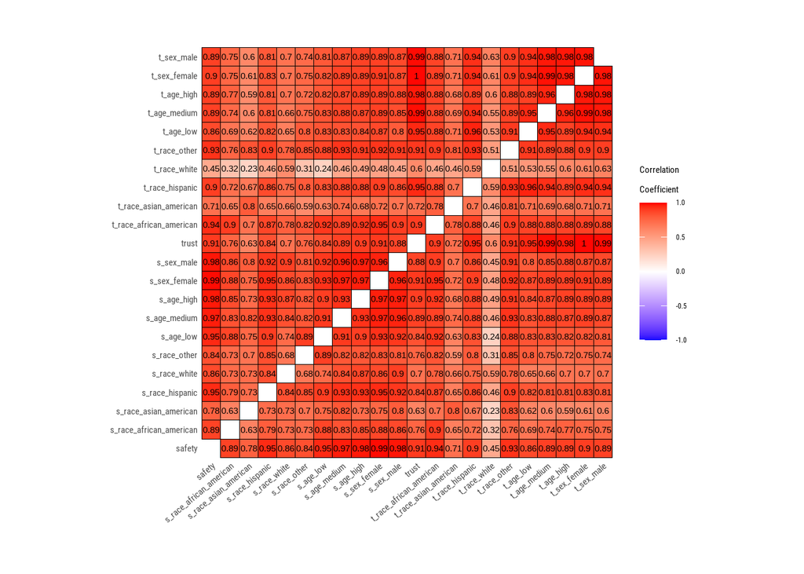

```r
plot_correlate(eda_sentiment[-c(1)])
```

## Correlations of Note

### Relationship between Safety and Trust

Before analysis, I would assume safety and trust are highly correlated.

Safety and Trust have a correlation of 0.9107112, giving strong evidence to this assumption.

All of the variables have a positive correlation to suggest that general increase in trust and safety means a increase in safety and trust sentiment to all groups categorized in this data set. This is not a novel finding, but is an important one because negative correlations would suggest efforts to increase safety and trust sentiment scores could correlate with a group feeling a negative impact towards their personal safety and trust sentiment towards the police.

We can continue this analysis with the assumption that increases in safety and trust police sentiment scores are positively correlated across all groups surveyed in the 77 communities.

# ANOVA-tests

In this section, I am examining the notable differences in trust and safety of police sentiment scores from the mean analysis above.

## On Safety

As referenced in the primary describe analysis, here are the anova tests to check for differences in groups identified in the dataset on their perception of safety sentiment.

```r
summary(aov(eda_sentiment$safety ~ eda_sentiment$s_race_african_american))
```

```
##                                       Df Sum Sq Mean Sq F value Pr(>F)
## eda_sentiment$s_race_african_american  1 2082.4  2082.4   271.6 <2e-16 ***
## Residuals                             75  574.9     7.7
## ---
## Signif. codes:  0 '***' 0.001 '**' 0.01 '*' 0.05 '.' 0.1 ' ' 1
```

```r
summary(aov(eda_sentiment$safety ~ eda_sentiment$s_race_white))
```

```
##                            Df Sum Sq Mean Sq F value Pr(>F)
## eda_sentiment$s_race_white  1 1979.1    1979   218.9 <2e-16 ***
## Residuals                  75  678.2       9
## ---
## Signif. codes:  0 '***' 0.001 '**' 0.01 '*' 0.05 '.' 0.1 ' ' 1
```

```r
summary(aov(eda_sentiment$safety ~ eda_sentiment$s_race_other))
```

```
##                            Df Sum Sq Mean Sq F value Pr(>F)
## eda_sentiment$s_race_other  1 1883.2  1883.2   182.4 <2e-16 ***
## Residuals                  75  774.1    10.3
## ---
## Signif. codes:  0 '***' 0.001 '**' 0.01 '*' 0.05 '.' 0.1 ' ' 1
```

```r
summary(aov(eda_sentiment$safety ~ eda_sentiment$s_age_high))
```

```
##                          Df Sum Sq Mean Sq F value Pr(>F)
## eda_sentiment$s_age_high  1 2542.6  2542.6    1662 <2e-16 ***
## Residuals                75  114.7     1.5
## ---
## Signif. codes:  0 '***' 0.001 '**' 0.01 '*' 0.05 '.' 0.1 ' ' 1
```

```r
summary(aov(eda_sentiment$s_race_white ~ eda_sentiment$s_race_african_american))
```

```
##                                       Df Sum Sq Mean Sq F value   Pr(>F)
## eda_sentiment$s_race_african_american  1  679.7   679.7   87.61 3.09e-14 ***
## Residuals                             75  581.9     7.8
## ---
## Signif. codes:  0 '***' 0.001 '**' 0.01 '*' 0.05 '.' 0.1 ' ' 1
```

```r
summary(aov(eda_sentiment$s_race_white ~ eda_sentiment$s_race_other))
```

```
##                            Df Sum Sq Mean Sq F value   Pr(>F)
## eda_sentiment$s_race_other  1  583.9   583.9   64.63 1.01e-11 ***
## Residuals                  75  677.7     9.0
## ---
## Signif. codes:  0 '***' 0.001 '**' 0.01 '*' 0.05 '.' 0.1 ' ' 1
```

## On Trust

```r
summary(aov(eda_sentiment$trust ~ eda_sentiment$t_race_african_american))
```

```
##                                       Df Sum Sq Mean Sq F value Pr(>F)
## eda_sentiment$t_race_african_american  1   4006    4006   325.8 <2e-16 ***
## Residuals                             75    922      12
## ---
## Signif. codes:  0 '***' 0.001 '**' 0.01 '*' 0.05 '.' 0.1 ' ' 1
```

```r
summary(aov(eda_sentiment$trust ~ eda_sentiment$t_race_asian_american))
```

```
##                                     Df Sum Sq Mean Sq F value   Pr(>F)
## eda_sentiment$t_race_asian_american  1   2531    2531   79.18 2.33e-13 ***
## Residuals                           75   2398      32
## ---
## Signif. codes:  0 '***' 0.001 '**' 0.01 '*' 0.05 '.' 0.1 ' ' 1
```

```r
summary(aov(eda_sentiment$trust ~ eda_sentiment$t_race_other))
```

```
##                            Df Sum Sq Mean Sq F value Pr(>F)
## eda_sentiment$t_race_other  1   4124    4124   384.1 <2e-16 ***
## Residuals                  75    805      11
## ---
## Signif. codes:  0 '***' 0.001 '**' 0.01 '*' 0.05 '.' 0.1 ' ' 1
```

```r
summary(aov(eda_sentiment$trust ~ eda_sentiment$t_race_white))
```

```
##                            Df Sum Sq Mean Sq F value   Pr(>F)
## eda_sentiment$t_race_white  1   1754  1753.9   41.44 1.03e-08 ***
## Residuals                  75   3175    42.3
## ---
## Signif. codes:  0 '***' 0.001 '**' 0.01 '*' 0.05 '.' 0.1 ' ' 1
```

```r
summary(aov(eda_sentiment$trust ~ eda_sentiment$t_age_low))
```

```
##                         Df Sum Sq Mean Sq F value Pr(>F)
## eda_sentiment$t_age_low  1   4475    4475   740.6 <2e-16 ***
## Residuals               75    453       6
## ---
## Signif. codes:  0 '***' 0.001 '**' 0.01 '*' 0.05 '.' 0.1 ' ' 1
```

```r
summary(aov(eda_sentiment$trust ~ eda_sentiment$t_age_high))
```

```
##                          Df Sum Sq Mean Sq F value Pr(>F)
## eda_sentiment$t_age_high  1   4711    4711    1625 <2e-16 ***
## Residuals                75    217       3
## ---
## Signif. codes:  0 '***' 0.001 '**' 0.01 '*' 0.05 '.' 0.1 ' ' 1
```

```r
summary(aov(eda_sentiment$t_race_white ~ eda_sentiment$t_race_african_american))
```

```
##                                       Df Sum Sq Mean Sq F value   Pr(>F)
## eda_sentiment$t_race_african_american  1  532.6   532.6   20.38 2.31e-05 ***
## Residuals                             75 1959.7    26.1
## ---
## Signif. codes:  0 '***' 0.001 '**' 0.01 '*' 0.05 '.' 0.1 ' ' 1
```

```r
summary(aov(eda_sentiment$t_age_low ~ eda_sentiment$t_age_high))
```

```
##                          Df Sum Sq Mean Sq F value Pr(>F)
## eda_sentiment$t_age_high  1 2494.6  2494.6   284.5 <2e-16 ***
## Residuals                75  657.6     8.8
## ---
## Signif. codes:  0 '***' 0.001 '**' 0.01 '*' 0.05 '.' 0.1 ' ' 1
```

```r
summary(aov(eda_sentiment$t_race_white ~ eda_sentiment$t_race_other))
```

```
##                            Df Sum Sq Mean Sq F value Pr(>F)
## eda_sentiment$t_race_other  1    652   652.0   26.57  2e-06 ***
## Residuals                  75   1840    24.5
## ---
## Signif. codes:  0 '***' 0.001 '**' 0.01 '*' 0.05 '.' 0.1 ' ' 1
```

# ANOVA Interactions

## Safety

```r
summary(aov(data = eda_sentiment, safety ~ s_race_white + s_race_other + s_race_white*s_race_other))
```

```
##                           Df Sum Sq Mean Sq F value   Pr(>F)
## s_race_white               1 1979.1  1979.1 442.563  < 2e-16 ***
## s_race_other               1  320.9   320.9  71.764 1.83e-12 ***
## s_race_white:s_race_other  1   30.8    30.8   6.891   0.0105 *
## Residuals                 73  326.5     4.5
## ---
## Signif. codes:  0 '***' 0.001 '**' 0.01 '*' 0.05 '.' 0.1 ' ' 1
```

```r
summary(aov(data = eda_sentiment, safety ~ s_race_white + s_race_african_american + s_race_white*s_race_african_american))
```

```
##                                      Df Sum Sq Mean Sq F value   Pr(>F)
## s_race_white                          1 1979.1  1979.1 494.414  < 2e-16 ***
## s_race_african_american               1  365.2   365.2  91.240 1.73e-14 ***
## s_race_white:s_race_african_american  1   20.7    20.7   5.183   0.0257 *
## Residuals                            73  292.2     4.0
## ---
## Signif. codes:  0 '***' 0.001 '**' 0.01 '*' 0.05 '.' 0.1 ' ' 1
```

## Trust

```r
summary(aov(data = eda_sentiment, trust ~ t_race_african_american + t_race_other + t_race_african_american*t_race_other  ))
```

```
##                                      Df Sum Sq Mean Sq F value   Pr(>F)
## t_race_african_american               1   4006    4006  458.34  < 2e-16 ***
## t_race_other                          1    271     271   30.99 4.07e-07 ***
## t_race_african_american:t_race_other  1     13      13    1.52    0.222
## Residuals                            73    638       9
## ---
## Signif. codes:  0 '***' 0.001 '**' 0.01 '*' 0.05 '.' 0.1 ' ' 1
```

```r
summary(aov(data = eda_sentiment, trust ~ t_race_african_american + t_race_asian_american + t_race_african_american*t_race_asian_american))
```

```
##                                               Df Sum Sq Mean Sq F value Pr(>F)
## t_race_african_american                        1   4006    4006 324.843 <2e-16
## t_race_asian_american                          1      3       3   0.205  0.652
## t_race_african_american:t_race_asian_american  1     19      19   1.574  0.214
## Residuals                                     73    900      12
##
## t_race_african_american                       ***
## t_race_asian_american
## t_race_african_american:t_race_asian_american
## Residuals
## ---
## Signif. codes:  0 '***' 0.001 '**' 0.01 '*' 0.05 '.' 0.1 ' ' 1
```

```r
summary(aov(data = eda_sentiment, trust ~ t_age_low + t_age_high + t_age_low*t_age_high))
```

```
##                      Df Sum Sq Mean Sq  F value Pr(>F)
## t_age_low             1   4475    4475 6455.162 <2e-16 ***
## t_age_high            1    399     399  575.791 <2e-16 ***
## t_age_low:t_age_high  1      3       3    4.951 0.0292 *
## Residuals            73     51       1
## ---
## Signif. codes:  0 '***' 0.001 '**' 0.01 '*' 0.05 '.' 0.1 ' ' 1
```

# Final Considerations for further analysis

## emphasis on individual communities

In the next steps, I want to bucket communities how the group sees fit for divvy. Treating each community as equal observations in the analysis is not the strongest way to approach this data. Further feedback from the rest of the violence and enforcement team, as well as the census group will inform this decision next class.

## for divvy

This analysis can be used to identify groups within specific communities where divvy is trying to operate and expand to be more equitable.

Next steps with this analysis can include taking the identified groups that feel significantly less safe and trustworthy towards the police. Marking the relevant communities from other groups data sets, and seeing where they stand in terms of trust and safety sentiment scores is important in considering which groups feel safe and secure when out on the road.

If these group’s sentiments towards safety and trust are not identified in the analysis, then equaticity cannot map a full story to explain the necessary steps towards making bike-sharing more equitable.

Data from the rest of the violence and enforcement team will be merged with this data set with the foreign key as ‘Community’